# SKILL ENHANCEMENT COURSE ANALYTICS / COMPUTING WITH PYTHON CLASS ASSIGNMENT

## Overfitting and Underfitting in Machine Learning

### Overfitting

**Definition:**  
Overfitting occurs when a machine learning model learns not only the underlying patterns in the training data but also the noise and random fluctuations. As a result, the model performs very well on the training data but poorly on unseen (test) data because it fails to generalize.

**Practical Example:**  
Suppose you train a polynomial regression model with a very high degree on a small housing dataset. The model fits every data point in the training set perfectly, but when predicting prices for new houses, its predictions are inaccurate and erratic.

**Symptoms:**

- High accuracy on training data, low accuracy on test data.
- Model is too complex relative to the amount of data.

### Underfitting

**Definition:**  
Underfitting happens when a model is too simple to capture the underlying structure of the data. It performs poorly on both training and test data.

**Practical Example:**  
Using a linear regression model to fit data that has a clear nonlinear relationship (e.g., quadratic or exponential trend). The model cannot capture the complexity, resulting in high errors.

**Symptoms:**

- Poor performance on both training and test data.
- Model is too simple for the problem.

## Overfitting Example in Practice

In the California housing dataset, if you use a very complex model (e.g., a high-degree polynomial regression or a decision tree with no depth limit), the model may fit the training data extremely well but fail to predict new house prices accurately.

## Strategies to Mitigate Overfitting: Regularization

**Regularization** adds a penalty to the loss function to discourage overly complex models (large coefficients), helping the model generalize better.

- **L1 Regularization (Lasso):**  
  Adds a penalty equal to the absolute value of the coefficients. It can shrink some coefficients to zero, effectively performing feature selection.
- **L2 Regularization (Ridge):**  
  Adds a penalty equal to the square of the coefficients. It shrinks all coefficients but does not set them exactly to zero.

**Other Strategies:**

- Use simpler models.
- Gather more training data.
- Use cross-validation to tune model complexity.
- Prune decision trees or limit model parameters.

**Summary:**

- Overfitting: Model too complex, fits noise, poor generalization.
- Underfitting: Model too simple, misses patterns, poor performance.
- Regularization (L1/L2) helps control model complexity and reduce overfitting.

# Section E

Question 1: Write a Python script to identify and remove duplicate rows from a large dataset using Pandas. Provide a detailed explanation of how Pandas handles duplicates.

## Identifying and Removing Duplicate Rows in Pandas

To efficiently identify and remove duplicate rows from a large dataset using Pandas, you can use the `duplicated()` and `drop_duplicates()` methods.

### Example Script

```
import pandas as pd

# Simulate a large dataset with duplicates
data = {
    'ID': [1, 2, 3, 4, 2, 5, 3, 6],
    'Name': ['Alice', 'Bob', 'Charlie', 'David', 'Bob', 'Eve', 'Charlie', 'Frank'],
    'Score': [85, 90, 95, 88, 90, 92, 95, 87]
}
df = pd.DataFrame(data)

print("Original DataFrame:")
print(df)

# Identify duplicate rows (all columns)
duplicates = df.duplicated()
print("\nDuplicate rows (True = duplicate):")
print(duplicates)

# Remove duplicate rows (keep first occurrence)
df_no_duplicates = df.drop_duplicates()
print("\nDataFrame after removing duplicates:")
print(df_no_duplicates)
```

### How Pandas Handles Duplicates

- **`duplicated()`**: Returns a Boolean Series indicating whether each row is a duplicate of a previous row. By default, it considers all columns.
  - `df.duplicated()` marks `True` for every row that is a duplicate of a previous row.
  - You can specify columns: `df.duplicated(subset=['Name', 'Score'])`
  - The `keep` parameter controls which duplicates to mark (`'first'`, `'last'`, or `False` for all).
- **`drop_duplicates()`**: Removes duplicate rows, keeping the first occurrence by default.
  - `df.drop_duplicates()` removes all but the first occurrence of each duplicate row.
  - You can specify columns and the `keep` parameter as above.

#### Notes:

- Both methods are efficient for large datasets.
- By default, the index is not reset after removing duplicates.
- You can remove duplicates in-place with `inplace=True`.

**Summary:**  
Pandas makes it easy to detect and remove duplicates, ensuring data integrity and preventing issues in downstream analysis.

```python
import pandas as pd

# Simulate a large dataset with duplicates
data = {
    'ID': [1, 2, 3, 4, 2, 5, 3, 6],
    'Name': ['Alice', 'Bob', 'Charlie', 'David', 'Bob', 'Eve', 'Charlie', 'Frank'],
    'Score': [85, 90, 95, 88, 90, 92, 95, 87]
}
df = pd.DataFrame(data)

print("Original DataFrame:")
print(df)

# Identify duplicate rows (all columns)
duplicates = df.duplicated()
print("\nDuplicate rows (True = duplicate):")
print(duplicates)

# Remove duplicate rows (keep first occurrence)
df_no_duplicates = df.drop_duplicates()
print("\nDataFrame after removing duplicates:")
print(df_no_duplicates)
```

```
Original DataFrame:
   ID     Name  Score
0   1    Alice     85
1   2      Bob     90
2   3  Charlie     95
3   4    David     88
4   2      Bob     90
5   5      Eve     92
6   3  Charlie     95
7   6    Frank     87

Duplicate rows (True = duplicate):
0    False
1    False
2    False
3    False
4     True
5    False
6     True
7    False
dtype: bool

DataFrame after removing duplicates:
   ID     Name  Score
0   1    Alice     85
1   2      Bob     90
2   3  Charlie     95
3   4    David     88
5   5      Eve     92
7   6    Frank     87
```

Question 2: Explain the importance of handling missing values in a dataset. Write Python code that demonstrates different methods to handle missing values (drop, fill, or interpolate).

```python
import pandas as pd
import numpy as np

# Create a sample DataFrame with missing values
data_missing = {
    'ID': [1, 2, 3, 4, 5],
    'Name': ['Alice', 'Bob', np.nan, 'David', 'Eve'],
    'Score': [85, np.nan, 95, 88, 92]
}
df_missing = pd.DataFrame(data_missing)
print("Original DataFrame with missing values:")
print(df_missing)

# 1. Drop rows with any missing values
df_drop = df_missing.dropna()
print("\nAfter dropping rows with missing values:")
print(df_drop)

# 2. Fill missing values with a constant (e.g., 0 or 'Unknown')
df_fill = df_missing.fillna({'Name': 'Unknown', 'Score': 0})
print("\nAfter filling missing values with constants:")
print(df_fill)

# 3. Interpolate missing values (numeric columns only)
df_interp = df_missing.copy()
df_interp['Score'] = df_interp['Score'].interpolate()
print("\nAfter interpolating missing numeric values:")
print(df_interp)
```

```
Original DataFrame with missing values:
   ID   Name  Score
0   1  Alice   85.0
1   2    Bob    NaN
2   3    NaN   95.0
3   4  David   88.0
4   5    Eve   92.0

After dropping rows with missing values:
   ID   Name  Score
0   1  Alice   85.0
3   4  David   88.0
4   5    Eve   92.0

After filling missing values with constants:
   ID     Name  Score
0   1    Alice   85.0
1   2      Bob    0.0
2   3  Unknown   95.0
3   4    David   88.0
4   5      Eve   92.0

After interpolating missing numeric values:
   ID   Name  Score
0   1  Alice   85.0
1   2    Bob   90.0
2   3    NaN   95.0
3   4  David   88.0
4   5    Eve   92.0
```

## Importance of Handling Missing Values in a Dataset

Handling missing values is a crucial step in data preprocessing for the following reasons:

- **Data Integrity**: Missing values can distort statistical analyses and lead to incorrect conclusions. Many algorithms cannot handle missing data and may fail or produce unreliable results.
- **Bias Prevention**: If missing values are not handled properly, they can introduce bias. For example, simply dropping rows with missing values may disproportionately remove certain groups, skewing the dataset.
- **Model Performance**: Machine learning models often require complete data. Missing values can reduce the amount of usable data, decrease model accuracy, or cause errors during training and prediction.
- **Accurate Insights**: Properly handling missing data ensures that analyses and models reflect the true patterns in the data, leading to more reliable insights and decisions.

**Common strategies to handle missing values:**

- Removing rows or columns with missing data (if the proportion is small)
- Filling (imputing) missing values with statistical measures (mean, median, mode)
- Using advanced imputation techniques (e.g., KNN, regression)
- Interpolating values for time series data

**Summary:**  
Addressing missing values is essential to maintain data quality, prevent bias, and ensure robust, accurate analysis and modeling.

Question 3: Illustrate the concept of indexing and slicing in Pandas DataFrame. Provide examples of selecting specific rows, columns, and sub-sections of the DataFrame.

```python
# Illustrating indexing and slicing in Pandas DataFrame

# Display the original DataFrame
print("Original DataFrame:")
print(df)

# 1. Selecting a specific column (as a Series)
print("\nSelect the 'Name' column:")
print(df['Name'])

# 2. Selecting multiple columns (as a DataFrame)
print("\nSelect 'Name' and 'Score' columns:")
print(df[['Name', 'Score']])

# 3. Selecting specific rows by index
print("\nSelect rows with index 2 and 4:")
print(df.loc[[2, 4]])

# 4. Slicing rows by position (using iloc)
print("\nSelect first three rows:")
print(df.iloc[:3])

# 5. Selecting a sub-section (rows 1 to 4, columns 'Name' and 'Score')
print("\nSelect rows 1 to 4 and columns 'Name' and 'Score':")
print(df.loc[1:4, ['Name', 'Score']])

# 6. Conditional selection (rows where Score > 90)
print("\nRows where Score > 90:")
print(df[df['Score'] > 90])

# --- Explanation ---
print("""
Explanation:
- Selecting columns: Use df['col'] for a single column (Series), or df[['col1', 'col2']] for multiple columns (DataFrame).
- Selecting rows: Use df.loc[] for label-based indexing, and df.iloc[] for position-based indexing.
- Slicing: df.iloc[start:end] selects rows by integer position.
- Sub-sections: Combine row and column selection, e.g., df.loc[rows, columns].
- Conditional selection: Use boolean indexing, e.g., df[df['Score'] > 90], to filter rows based on conditions.
""")
```

```
Original DataFrame:
   ID     Name  Score
0   1    Alice     85
1   2      Bob     90
2   3  Charlie     95
3   4    David     88
4   2      Bob     90
5   5      Eve     92
6   3  Charlie     95
7   6    Frank     87

Select the 'Name' column:
0      Alice
1        Bob
2    Charlie
3      David
4        Bob
5        Eve
6    Charlie
7      Frank
Name: Name, dtype: object

Select 'Name' and 'Score' columns:
      Name  Score
0    Alice     85
1      Bob     90
2  Charlie     95
3    David     88
4      Bob     90
5      Eve     92
6  Charlie     95
7    Frank     87

Select rows with index 2 and 4:
   ID     Name  Score
2   3  Charlie     95
4   2      Bob     90

Select first three rows:
   ID     Name  Score
```

[output cut: 8 more lines]

```
3    David     88
4      Bob     90

Rows where Score > 90:
   ID     Name  Score
2   3  Charlie     95
5   5      Eve     92
6   3  Charlie     95

Explanation:
- Selecting columns: Use df['col'] for a single column (Series), or df[['col1', 'col2']] for multiple columns (DataFrame).
- Selecting rows: Use df.loc[] for label-based indexing, and df.iloc[] for position-based indexing.
- Slicing: df.iloc[start:end] selects rows by integer position.
- Sub-sections: Combine row and column selection, e.g., df.loc[rows, columns].
- Conditional selection: Use boolean indexing, e.g., df[df['Score'] > 90], to filter rows based on conditions.
```

# Section 6

Question 1. Demonstrate how to create and customize interactive plots using Plotly. Explain how it differs from Matplotlib and Seaborn for data visualization.

## Creating and Customizing Interactive Plots with Plotly

**Plotly** is a powerful Python library for creating interactive, publication-quality visualizations. Unlike Matplotlib and Seaborn, which primarily generate static images, Plotly produces interactive plots that users can zoom, pan, hover, and export directly from the browser.

### How Plotly Differs from Matplotlib and Seaborn

| Feature | Plotly | Matplotlib/Seaborn |
| --- | --- | --- |
| **Interactivity** | Fully interactive by default | Mostly static (limited interactivity with mpld3 or widgets) |
| **Ease of Use** | High-level API (Plotly Express) | Matplotlib: low-level, Seaborn: high-level for stats |
| **Web Integration** | Native HTML/JS output | Static images (PNG, SVG, PDF) |
| **Customization** | Extensive, via JSON-like syntax | Extensive, but sometimes verbose |
| **3D/Maps** | Built-in support | Limited (Matplotlib 3D is basic) |
| **Performance** | Slower for very large datasets | Faster for static, large datasets |

### Example Use Cases

- **Dashboards**: Plotly is ideal for building interactive dashboards (e.g., with Dash).
- **Data Exploration**: Hover tooltips and zooming make it easy to explore data visually.
- **Presentations**: Interactive plots engage audiences and allow dynamic exploration.

```python
import plotly.express as px
import pandas as pd

# Sample DataFrame
df = pd.DataFrame({
    'ID': [1, 2, 3, 4, 5, 6],
    'Name': ['Alice', 'Bob', 'Charlie', 'David', 'Eve', 'Frank'],
    'Score': [85, 90, 95, 88, 92, 87]
})

# Create an interactive scatter plot
fig = px.scatter(
    df,
    x='ID',
    y='Score',
    color='Name',
    title='Interactive Score Plot',
    labels={'Score': 'Test Score', 'ID': 'Student ID'},
    hover_data=['Name']
)

# Customize layout
fig.update_layout(
    xaxis=dict(showgrid=True),
    yaxis=dict(showgrid=True),
    legend_title_text='Student Name'
)

fig.show()
```

[output not shown]

Question 2. Write a Python script to perform time series analysis and visualization on a dataset. Explain how to identify trends, seasonality, and anomalies.

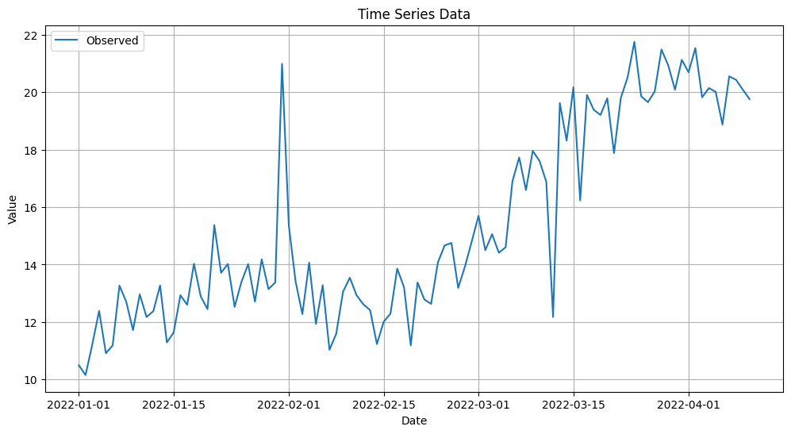

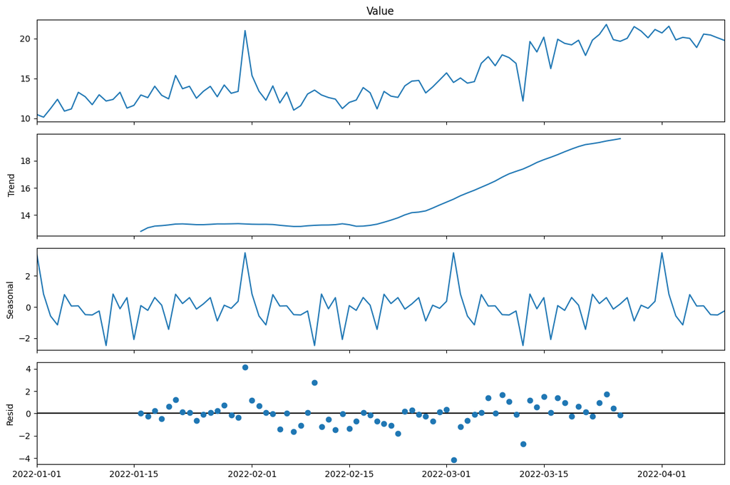

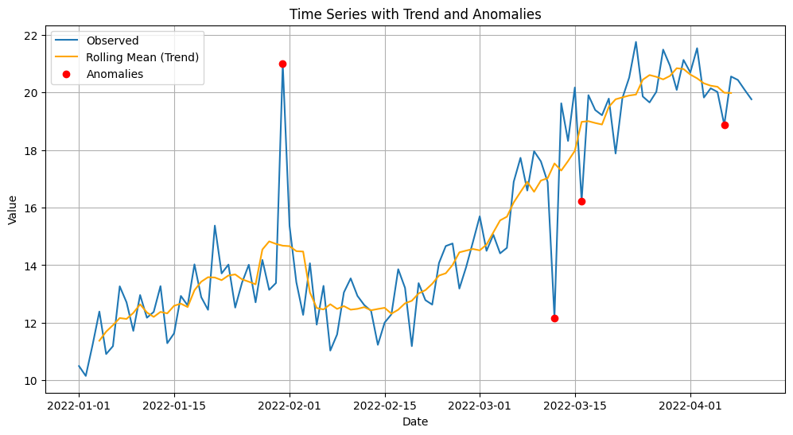

```
How to identify:
- Trend: Look for long-term upward or downward movement (see rolling mean or decomposition trend).
- Seasonality: Look for repeating patterns at regular intervals (see decomposition seasonal component).
- Anomalies: Points that deviate significantly from the trend/seasonality (highlighted in red).
```

```python
import pandas as pd
import numpy as np
from statsmodels.tsa.seasonal import seasonal_decompose

import matplotlib.pyplot as plt

# Create a sample time series dataset
np.random.seed(42)
date_range = pd.date_range(start='2022-01-01', periods=100, freq='D')
trend = np.linspace(10, 20, 100)  # upward trend
seasonality = 2 * np.sin(np.linspace(0, 3 * np.pi, 100))  # seasonal pattern
noise = np.random.normal(0, 1, 100)  # random noise
anomaly = np.zeros(100)
anomaly[30] = 8  # inject an anomaly
anomaly[70] = -6

values = trend + seasonality + noise + anomaly

df_ts = pd.DataFrame({'Date': date_range, 'Value': values})
df_ts.set_index('Date', inplace=True)

# Plot the time series
plt.figure(figsize=(12, 6))
plt.plot(df_ts.index, df_ts['Value'], label='Observed')
plt.title('Time Series Data')
plt.xlabel('Date')
plt.ylabel('Value')
plt.legend()
plt.grid(True)
plt.show()

# Decompose the time series (trend, seasonality, residuals)

decomposition = seasonal_decompose(df_ts['Value'], model='additive', period=30)
fig = decomposition.plot()
fig.set_size_inches(12, 8)
plt.tight_layout()
plt.show()

# Identify anomalies (simple method: points far from rolling mean)
rolling_mean = df_ts['Value'].rolling(window=7, center=True).mean()
rolling_std = df_ts['Value'].rolling(window=7, center=True).std()
anomalies = df_ts[np.abs(df_ts['Value'] - rolling_mean) > 2 * rolling_std]

plt.figure(figsize=(12, 6))
plt.plot(df_ts.index, df_ts['Value'], label='Observed')
plt.plot(df_ts.index, rolling_mean, color='orange', label='Rolling Mean (Trend)')
plt.scatter(anomalies.index, anomalies['Value'], color='red', label='Anomalies', zorder=5)
plt.title('Time Series with Trend and Anomalies')
plt.xlabel('Date')
plt.ylabel('Value')
plt.legend()
plt.grid(True)
plt.show()

# --- Explanation ---
print("""
How to identify:
- Trend: Look for long-term upward or downward movement (see rolling mean or decomposition trend).
- Seasonality: Look for repeating patterns at regular intervals (see decomposition seasonal component).
- Anomalies: Points that deviate significantly from the trend/seasonality (highlighted in red).
""")
```

Question 3. Explain the importance of correlation in data analysis. Create a correlation matrix using Pandas and visualize it with a heatmap using Seaborn.

```
Correlation Matrix:
             ID     Score
ID     1.000000  0.132915
Score  0.132915  1.000000
```

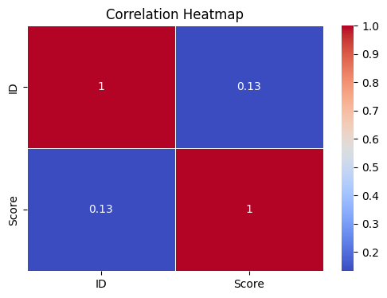

```python
import seaborn as sns

import matplotlib.pyplot as plt

# Calculate the correlation matrix for the numeric columns of DataFrame 'df'
corr_matrix = df.select_dtypes(include='number').corr()

print("Correlation Matrix:")
print(corr_matrix)

# Visualize the correlation matrix with a heatmap
plt.figure(figsize=(6, 4))
sns.heatmap(corr_matrix, annot=True, cmap='coolwarm', linewidths=0.5)
plt.title("Correlation Heatmap")
plt.show()

# Explanation:
# Correlation measures the strength and direction of the linear relationship between variables.
# In data analysis, understanding correlations helps identify which variables are related,
# detect multicollinearity, and select features for modeling.
# The heatmap visually highlights strong positive (closer to 1) and negative (closer to -1) correlations.
```